# Post Goals:

1. Introduction to single population nonparameteric inferences.
2. Perform shapiro-wilk test in R
3. Generate a normal Q-Q plot in R
4. Exact test for a population proportion.
5. One-Sample Sign Test for a Population Median

# Introduction to single population nonparameteric inferences.

**The basics**

- Are types of inferences made on a single population where the assumptions for parametric statistics are violated and do not apply.
- The inference is made about a population median.
- Test rely on less assumptions, but have smaller power to reject the $H_0$ when the population is normal.
- This post will discuss the hypothesis test and confidence inverval for nonparametric tests.
- Assumptions is that the data from from a random sample
- The random sample is representative of the entire population
- The R programming language will be used to carry out these calculations.

**How to idenfity if a nonparametric test is needed**

- A shapiro-wilk test suggest the sampled population is not normal.
- Histogram does not have a single peak and symetric tails.
- The data in normal q-q plot does not have a straight line along the diagonal expected and observe line (or z-quantiles versus the sample quantiles).

# Perform shapiro-wilk test in R

**The Basics**

- Shapiro-Wilk test test for normality
- Hypothesis test:
  - Null Hypothesis. $H_o:$ Sample population is normal. p-value is large.
  - Alternative Hypothesis $H_a:$ Sample population is not normal. p-value is small.

## Example 1

- Old faithful geyser data in R MASS Library
- Histogram for eruptions does not appear normally distributed
- Carry out a shapiro wilk test

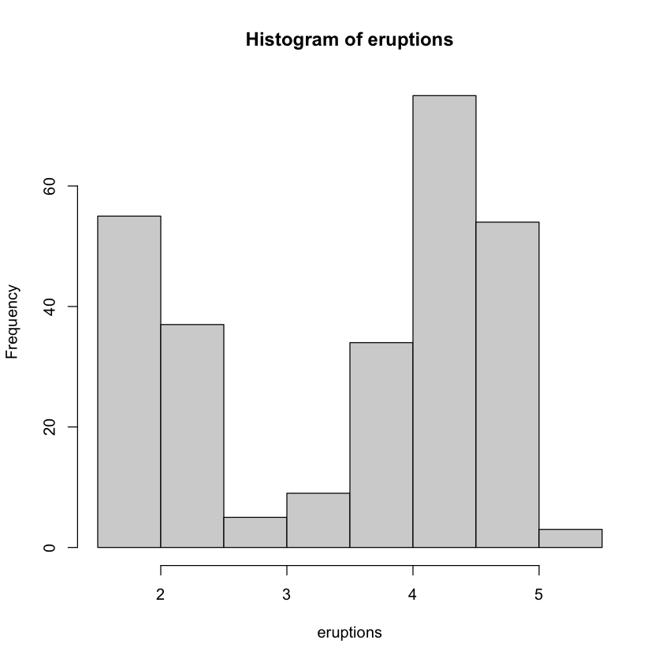

```r
library('MASS')
attach(faithful)
hist(eruptions)
```

## Shapiro Wilk Test

- `shapiro.test(vector)`

```r
shapiro.test(eruptions)
```

```
	Shapiro-Wilk normality test

data:  eruptions
W = 0.84592, p-value = 9.036e-16
```

## Example 1 p value is less than 0.05, reject $H_0$ Evidence to suggest the data is not normally distributed

# Generate a normal Q-Q plot in R

**The Basics**

- A nomral quantile-quantile plot is a good visual method to inspect if data is normally distributed.
- The plot is a set of x and y values that represents the obseved values on the y-axis and x-axis is the quantiles from N(0,1) distribution, also referred to z-coordinates in some spaces.
- The x-axis quantiles are chosed from an algoirthm so that the observed sample and the sample z-scores are matched up.
- The qq-plot will form a straight diagonal line if the sample is drawn from a normal population.

## Example 2

- Peform a Normal Q-Q plot on eruptions using the old faithful dataset
- `qqnorm(vector)`
- `qqline(vector)`

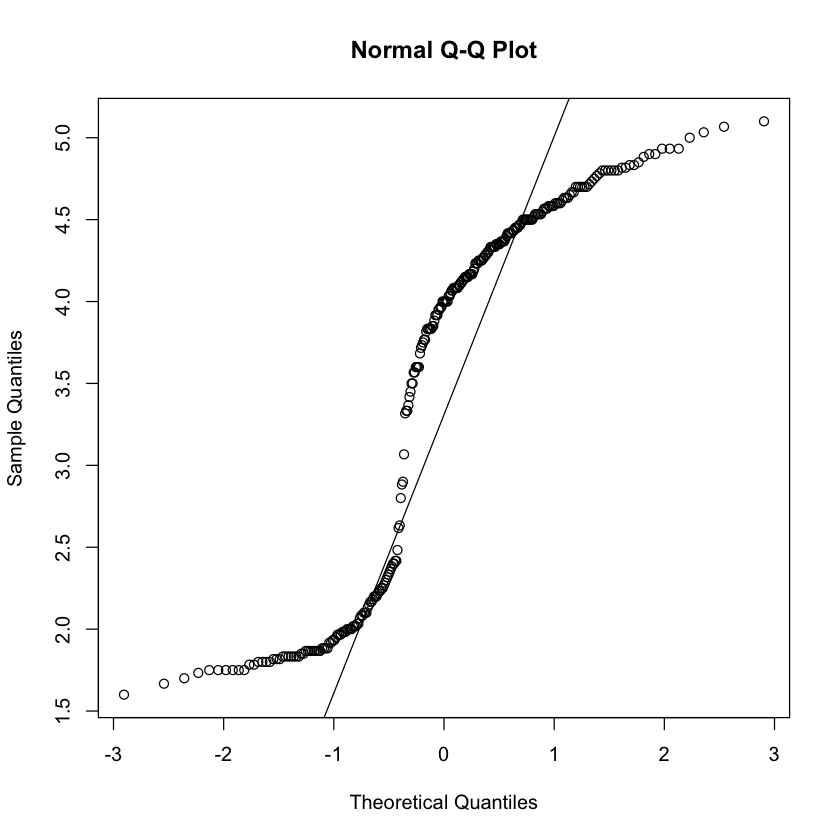

```r
qqnorm(eruptions)
qqline(eruptions)
```

## Example 2 The data does not form a diagonal line the data does not appear normally distributed.

# Exact test for a population proportion.

**The Basics**

- Hypothesis is similar to the z-test on population proportion although the only assumption is that the data comes form a random sample of units that are classified in a binary fashion.
- This is an ideal test to use when the “large enough sample” rule of thumb is not satisfied for the z-test for population proportion.
- The test in R is implemented with the `binom.test(x, n, p=P0, alt=TYPE, conf.level=CL)`

## Example 3

- 12% of Employees have been arriving late to work, and its believed to be due to the parking garage malfunctions preventing people from coming in.
- A new system has been implemented but we need to determine if the proportion of employees running late has decreased.
- $\alpha = 0.05$
- $H_0: p = 0.12$
- $H_a: p \leq 0.12$
- n = 250
- df = none for proportions
- 22 out of 250 late with new system

```r
binom.test(22, 250, p=0.12, alt='l', conf.level=0.95)
```

```
	Exact binomial test

data:  22 and 250
number of successes = 22, number of trials = 250, p-value = 0.06777
alternative hypothesis: true probability of success is less than 0.12
95 percent confidence interval:
 0.0000000 0.1232731
sample estimates:
probability of success
                 0.088
```

## Example 3 The p value is greater than 0.05 do not reject $H_0$

# One-Sample Sign Test for a Population Median.

**The Basics**

- This inference test is used when testing a population median $\tilde{\mu}$
- Hypothesis test:
  - Null Hypothesis. $H_o:\tilde{\mu} = \tilde{\mu_0} $
  - Alternative Hypothesis 2 sided: $H_o:\tilde{\mu} \neq \tilde{\mu_0}$
  - Alternative Hypothesis 1 sided lower tail: $H_o:\tilde{\mu} < \tilde{\mu_0} $
  - Alternative Hypothesis 1 sided upper tail: $H_o:\tilde{\mu} > \tilde{\mu_0} $
- The model assumes the data are from a random sample
- The data is continuous numeric variable
- $\tilde{\mu}$ is $p = \frac{1}{2}$
- The test in R is implemented with the `binom.test(x, n, p=P0, alt=TYPE, conf.level=CL)`

## Example 3

- Is the proportion of the data 0.5 or greater than 0.5
- $\alpha = 0.05$
- $H_0: p = 0.5$
- $H_a: p > 0.5$

```r
data <- c(1.6, 2,2.7,1.3,2,1.3,0.3,0.9,1.2,1.2,0.2,1.3,5,0.8,7.4,3,0.6,1.8,2.5,0.3)
```

```r
# count data greater than 1
x <- sum(data>1); x
```

14

```r
# number of data points
n_data <- length(data); n_data
```

20

```r
binom.test(x, n_data, p=0.5, alt='g', conf.level=.95)
```

```
	Exact binomial test

data:  x and n_data
number of successes = 14, number of trials = 20, p-value = 0.05766
alternative hypothesis: true probability of success is greater than 0.5
95 percent confidence interval:
 0.4921816 1.0000000
sample estimates:
probability of success
                   0.7
```